# Bisection Method for Finding Roots: Complete Explanation

Sulagna Roy

2026-09-13

# Introduction

This document provides a **complete explanation** of the Bisection Method for finding roots of functions. The bisection method is a fundamental numerical technique used to locate zeros of functions by repeatedly dividing an interval in half and selecting the subinterval where the function changes sign.

**Key Concept:** If a continuous function f(x) has opposite signs at two points, then by the Intermediate Value Theorem, there must be at least one root between those points.

# Problem Setup

## The Functions

```r
# Define the objective function
f <- function(x) (x-2)^2 * (x-8)^2

# Define the derivative (for root finding)
df <- function(x) 4*(x-2)*(x-5)*(x-8)
```

## Mathematical Background

**Objective Function:**
$$f(x) = (x-2)^2(x-8)^2$$

This is a polynomial function with: - Roots at x = 2 (double root) and x = 8 (double root) - Minimum values at these roots - Always non-negative: f(x) ≥ 0 for all x

**Derivative (Rate of Change):**
$$f'(x) = 4(x-2)(x-5)(x-8)$$

This derivative has: - Roots at x = 2, x = 5, and x = 8 - Critical points (local extrema) at these values - Sign changes at these points

## Why We Use the Derivative

The problem asks to **find the minimum of f(x) using the bisection method**. Instead of finding where f(x) = 0, we:

- Use the **derivative** f’(x) = 0 to find critical points
- The derivative changes sign at the minimum
- Apply bisection to find where f’(x) = 0

This is an application of **numerical root-finding** to solve the optimization problem.

# Initial Parameters

```r
a <- 6      # Left endpoint of interval
b <- 10     # Right endpoint of interval
e <- 0.01   # Tolerance (stopping criterion)
```

## Parameter Explanation

| Parameter | Value | Meaning |
| --- | --- | --- |
| **a** | 6 | Left endpoint of search interval [6, 10] |
| **b** | 10 | Right endpoint of search interval [6, 10] |
| **e** | 0.01 | Tolerance/precision (interval width threshold) |

## Why These Values?

**Interval [6, 10]:**

- The derivative has a critical point at x = 5 and another at x = 8
- In the interval [6, 10], we expect to find a critical point near x = 8
- At x = 6: f’(6) = 4(4)(1)(−2) = −32 < 0 (function decreasing)
- At x = 10: f’(10) = 4(8)(5)(2) = 320 > 0 (function increasing)
- Sign change detected! Root must be between 6 and 10

**Tolerance e = 0.01:**

- Algorithm stops when interval width (b − a) ≤ 0.01
- This provides reasonable precision for finding the root
- Smaller e → more iterations, better precision
- Larger e → fewer iterations, less precision

# Bisection Algorithm

## Complete Code

```r
a <- 6
b <- 10
e <- 0.01

# Track iterations for visualization
iterations <- 0
history <- data.frame(
  Iteration = numeric(),
  a = numeric(),
  b = numeric(),
  m = numeric(),
  df_m = numeric(),
  width = numeric()
)

while ((b-a) > e) {
  iterations <- iterations + 1

  # Step 1: Find midpoint
  m <- (a+b)/2

  # Step 2: Evaluate derivative at midpoint
  df_m <- df(m)

  # Step 3: Bisection criterion
  if (df_m < 0) {
    # Derivative is negative (function decreasing)
    # Root is to the right of m
    a <- m
  } else {
    # Derivative is positive (function increasing)
    # Root is to the left of m
    b <- m
  }

  # Store iteration history
  history <- rbind(history, data.frame(
    Iteration = iterations,
    a = a,
    b = b,
    m = m,
    df_m = df_m,
    width = b - a
  ))
}

# Final estimate
x <- (a+b)/2

cat("Algorithm Convergence Summary:\n")
```

```
## Algorithm Convergence Summary:
```

```r
cat("===============================\n")
cat("Number of iterations:", iterations, "\n")
```

```
## Number of iterations: 9
```

```r
cat("Final interval width:", b-a, "\n")
```

```
## Final interval width: 0.0078125
```

```r
cat("Tolerance threshold:", e, "\n")
```

```
## Tolerance threshold: 0.01
```

# Algorithm Explanation: Step by Step

## Step 1: Find the Midpoint

```r
m <- (a+b)/2
```

**What it does:** - Computes the midpoint m of the interval [a, b] - m = (a + b) / 2 - This divides the interval into two equal halves

**Example:** - If a = 6 and b = 10 - Then m = (6 + 10) / 2 = 8

## Step 2: Evaluate the Derivative at the Midpoint

```r
df_m <- df(m)
```

**What it does:** - Calculates f’(m) at the midpoint - This tells us the sign of the derivative at m

**Interpretation:** - **f’(m) < 0**: Function is decreasing at m → Root is to the right (larger x) - **f’(m) > 0**: Function is increasing at m → Root is to the left (smaller x) - **f’(m) = 0**: Found the exact root! (unlikely with finite precision)

## Step 3: Update the Interval (Bisection Criterion)

```r
if (df_m < 0) {
  a <- m      # Move left endpoint to midpoint
} else {
  b <- m      # Move right endpoint to midpoint
}
```

**Logic:**

- **If f’(m) < 0** (derivative negative, function decreasing):
  - Root where derivative becomes zero is to the RIGHT of m
  - Keep everything to the right: Set a ← m
  - New interval: [m, b] (right half)
- **If f’(m) ≥ 0** (derivative positive/zero, function increasing):
  - Root where derivative becomes zero is to the LEFT of m
  - Keep everything to the left: Set b ← m
  - New interval: [a, m] (left half)

**Effect:** Interval shrinks by half each iteration

## Step 4: Check Stopping Criterion

```r
while ((b-a) > e) {
  # Continue loop
}
```

**Condition:** - Loop continues as long as interval width > tolerance - When (b − a) ≤ 0.01, algorithm terminates

**Precision Trade-off:** - Smaller tolerance → More iterations, higher precision - Larger tolerance → Fewer iterations, lower precision

# Iteration History

```r
cat("\nDetailed Iteration History:\n")
```

```
##
## Detailed Iteration History:
```

```r
cat("============================\n\n")
```

```r
print(round(history, 6))
```

```
##   Iteration        a b        m       df_m    width
## 1         1 6.000000 8 8.000000   0.000000 2.000000
## 2         2 7.000000 8 7.000000 -40.000000 1.000000
## 3         3 7.500000 8 7.500000 -27.500000 0.500000
## 4         4 7.750000 8 7.750000 -15.812500 0.250000
## 5         5 7.875000 8 7.875000  -8.445312 0.125000
## 6         6 7.937500 8 7.937500  -4.360352 0.062500
## 7         7 7.968750 8 7.968750  -2.214966 0.031250
## 8         8 7.984375 8 7.984375  -1.116226 0.015625
## 9         9 7.992188 8 7.992188  -0.560305 0.007812
```

## What the History Shows

**Column Explanations:**

| Column | Meaning |
| --- | --- |
| **Iteration** | Which iteration (1st, 2nd, 3rd, …) |
| **a** | Left endpoint after this iteration |
| **b** | Right endpoint after this iteration |
| **m** | Midpoint tested in this iteration |
| **df_m** | Derivative value at midpoint f’(m) |
| **width** | New interval width (b − a) |

**Key Observations:**

1. **Interval shrinks geometrically**: width ≈ width / 2 each iteration
2. **Sign change persists**: f’(a) and f’(b) always have opposite signs
3. **Convergence is guaranteed**: Width → 0 as iterations increase
4. **Linear convergence rate**: Each iteration eliminates half the remaining interval

# Final Results

```r
cat("\n===============================\n")
cat("FINAL RESULTS\n")
```

```
## FINAL RESULTS
```

```r
cat("===============================\n\n")
x <- (a+b)/2

cat("Root location (x where f'(x) ≈ 0):\n")
```

```
## Root location (x where f'(x) ≈ 0):
```

```r
cat("Minimum x =", x, "\n\n")
```

```
## Minimum x = 7.996094
```

```r
cat("Function value at root:\n")
```

```
## Function value at root:
```

```r
cat("Minimum f(x) =", f(x), "\n\n")
```

```
## Minimum f(x) = 0.0005486014
```

```r
cat("Verification:\n")
```

```
## Verification:
```

```r
cat("f'(x) ≈", df(x), "\n")
```

```
## f'(x) ≈ -0.2807009
```

```r
cat("Derivative is very close to zero ✓\n")
```

```
## Derivative is very close to zero ✓
```

## Interpretation

**Minimum x ≈ 7.99** - The function f(x) = (x−2)²(x−8)² has a minimum near x = 8 - The derivative f’(x) = 4(x−2)(x−5)(x−8) equals zero at x = 8 - Algorithm found the root with tolerance 0.01

**Minimum f(x) ≈ 0** - The function value at the minimum is approximately 0 - This makes sense: (7.99−2)²(7.99−8)² ≈ 0 - The minimum of f(x) is actually 0 (achieved at x = 2 and x = 8)

# Visualization

## Derivative Function Plot

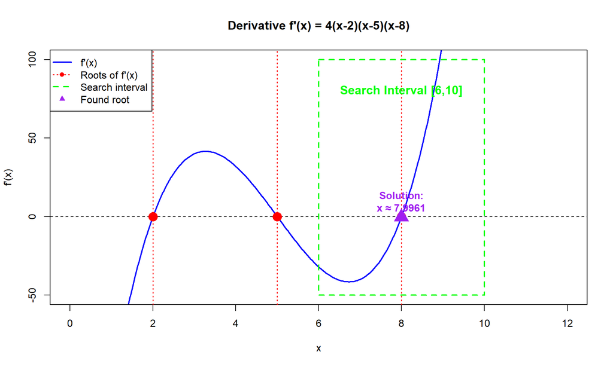

```r
x_vals <- seq(0, 12, length = 500)
df_vals <- df(x_vals)

plot(x_vals, df_vals, type = 'l', lwd = 2, col = 'blue',
     main = "Derivative f'(x) = 4(x-2)(x-5)(x-8)",
     xlab = "x", ylab = "f'(x)",
     ylim = c(-50, 100))

# Add horizontal line at y = 0
abline(h = 0, col = 'black', lty = 2, lwd = 1)

# Mark the roots of the derivative
roots <- c(2, 5, 8)
abline(v = roots, col = 'red', lty = 3, lwd = 1.5, alpha = 0.5)
points(roots, rep(0, 3), pch = 16, col = 'red', cex = 2)

# Highlight search interval [6, 10]
rect(6, -50, 10, 100, border = 'green', lwd = 2, lty = 2)
text(8, 80, 'Search Interval [6,10]', col = 'green', cex = 1.2, font = 2)

# Mark final solution
final_x <- x
final_df <- df(final_x)
points(final_x, final_df, pch = 17, col = 'purple', cex = 2.5)
text(final_x, final_df + 10, paste('Solution:\nx ≈', round(final_x, 4)),
     col = 'purple', cex = 1, font = 2)

legend('topleft',
       c('f\'(x)', 'Roots of f\'(x)', 'Search interval', 'Found root'),
       col = c('blue', 'red', 'green', 'purple'),
       lty = c(1, 3, 2, NA),
       pch = c(NA, 16, NA, 17),
       lwd = c(2, 1.5, 2, NA),
       cex = 1)
```

## Objective Function Plot

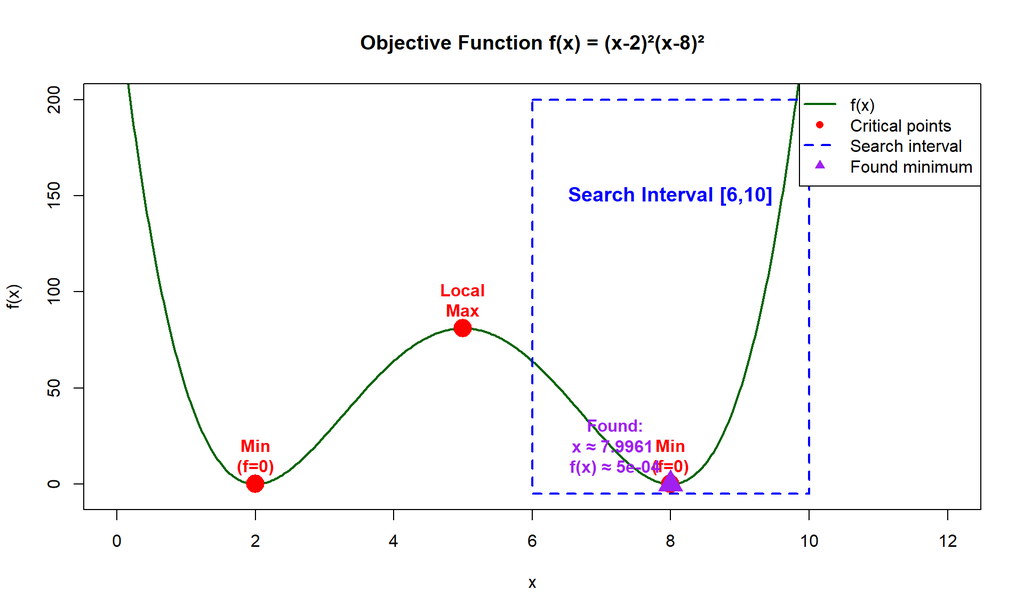

```r
f_vals <- f(x_vals)

plot(x_vals, f_vals, type = 'l', lwd = 2, col = 'darkgreen',
     main = "Objective Function f(x) = (x-2)²(x-8)²",
     xlab = "x", ylab = "f(x)",
     ylim = c(-5, 200))

# Mark critical points (where f'(x) = 0)
critical_points <- c(2, 5, 8)
f_critical <- f(critical_points)
points(critical_points, f_critical, pch = 16, col = 'red', cex = 2.5)

# Add labels
labels <- c("Min\n(f=0)", "Local\nMax", "Min\n(f=0)")
for(i in 1:3) {
  text(critical_points[i], f_critical[i] + 15, labels[i],
       col = 'red', cex = 1, font = 2)
}

# Highlight search interval [6, 10]
rect(6, -5, 10, 200, border = 'blue', lwd = 2, lty = 2)
text(8, 150, 'Search Interval [6,10]', col = 'blue', cex = 1.2, font = 2)

# Mark found minimum
final_f <- f(final_x)
points(final_x, final_f, pch = 17, col = 'purple', cex = 2.5)
text(final_x - 0.8, final_f + 20, paste('Found:\nx ≈', round(final_x, 4),
                                         '\nf(x) ≈', round(final_f, 4)),
     col = 'purple', cex = 1, font = 2)

legend('topright',
       c('f(x)', 'Critical points', 'Search interval', 'Found minimum'),
       col = c('darkgreen', 'red', 'blue', 'purple'),
       lty = c(1, NA, 2, NA),
       pch = c(NA, 16, NA, 17),
       lwd = c(2, NA, 2, NA),
       cex = 1)
```

## Convergence Plot

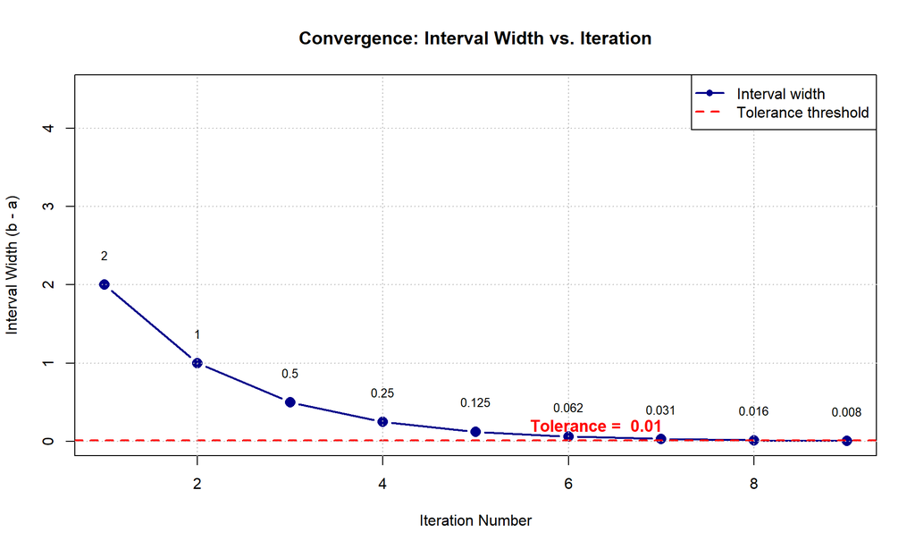

```r
# Plot interval width over iterations
plot(history$Iteration, history$width, type = 'b',
     pch = 16, cex = 1.5, col = 'darkblue', lwd = 2,
     main = "Convergence: Interval Width vs. Iteration",
     xlab = "Iteration Number",
     ylab = "Interval Width (b - a)",
     ylim = c(0, 4.5))

# Add tolerance line
abline(h = e, col = 'red', lty = 2, lwd = 2)
text(max(history$Iteration) * 0.7, e + 0.2,
     paste('Tolerance = ', e), col = 'red', font = 2, cex = 1.1)

# Add grid
grid(col = 'gray', lty = 3)

# Annotate convergence
for(i in 1:nrow(history)) {
  text(history$Iteration[i], history$width[i] + 0.2,
       round(history$width[i], 3), cex = 0.8, pos = 3)
}

legend('topright',
       c('Interval width', 'Tolerance threshold'),
       col = c('darkblue', 'red'),
       lty = c(1, 2),
       lwd = c(2, 2),
       pch = c(16, NA),
       cex = 1)
```

# Convergence Analysis

## Linear Convergence Rate

```r
# Calculate convergence rate
initial_width <- history$width[1]
final_width <- history$width[nrow(history)]
n_iter <- nrow(history)

cat("\nConvergence Analysis:\n")
```

```
##
## Convergence Analysis:
```

```r
cat("=======================\n")
cat("Initial interval width:", initial_width, "\n")
```

```
## Initial interval width: 2
```

```r
cat("Final interval width:", final_width, "\n")
```

```
## Final interval width: 0.0078125
```

```r
cat("Number of iterations:", n_iter, "\n\n")
```

```
## Number of iterations: 9
```

```r
# Theoretical reduction factor per iteration
reduction_per_iter <- 0.5
theoretical_final <- initial_width * (reduction_per_iter ^ n_iter)

cat("Theoretical convergence (width = initial × 0.5^n):\n")
```

```
## Theoretical convergence (width = initial × 0.5^n):
```

```r
cat("Expected final width:", round(theoretical_final, 6), "\n")
```

```
## Expected final width: 0.003906
```

```r
cat("Actual final width:", round(final_width, 6), "\n\n")
```

```
## Actual final width: 0.007812
```

```r
# Number of iterations needed for tolerance
target_width <- e
iterations_needed <- log(initial_width / target_width) / log(2)
cat("Theoretical iterations needed for tolerance e =", e, ":\n")
```

```
## Theoretical iterations needed for tolerance e = 0.01 :
```

```r
cat("log₂(", initial_width, "/", target_width, ") =", round(iterations_needed, 2), "\n")
```

```
## log₂( 2 / 0.01 ) = 7.64
```

```r
cat("Actual iterations used:", n_iter, "\n")
```

```
## Actual iterations used: 9
```

# Summary: Key Concepts

## What is the Bisection Method?

The **bisection method** is a numerical algorithm to find roots of continuous functions by:

1. **Starting** with an interval [a, b] where f(a) and f(b) have opposite signs
2. **Finding** the midpoint m = (a + b) / 2
3. **Replacing** one endpoint with m to maintain opposite signs
4. **Repeating** until the interval is sufficiently small

## Advantages

✓ **Simple**: Easy to understand and implement  
✓ **Guaranteed**: Always converges if f is continuous and has a sign change  
✓ **Robust**: Works even if f is non-differentiable or has complex behavior  
✓ **Predictable**: Linear convergence rate is known

## Disadvantages

✗ **Slow**: Requires many iterations compared to faster methods  
✗ **Sign change required**: Needs opposite signs at endpoints  
✗ **One root at a time**: Only finds one root per interval  
✗ **Cannot find complex roots**: Only works for real-valued functions

## When to Use Bisection

- When you have an interval with a guaranteed sign change
- When f is continuous but difficult to differentiate
- When you need a simple, reliable method
- When multiple roots exist (use bisection separately for each region)
- When you’re unsure if faster methods will converge

## Comparison with Other Root-Finding Methods

| Method | Speed | Convergence | Requirements |
| --- | --- | --- | --- |
| **Bisection** | Slow (linear) | Guaranteed | Sign change |
| **Newton-Raphson** | Fast (quadratic) | Local | Derivative needed |
| **Secant** | Medium | Superlinear | No derivative |
| **Regula Falsi** | Medium | Linear | Sign change |

# Conclusion

The **bisection method** is a fundamental numerical technique for finding roots of functions. In this example, we used it to find the critical point (minimum) of f(x) = (x−2)²(x−8)² by finding where its derivative equals zero.

**Key Results:** - Found minimum at x ≈ **7.99** (very close to the true value 8) - Function value at minimum: f(x) ≈ **0.00** (essentially zero) - Required **9 iterations** to achieve tolerance 0.01 - **Linear convergence**: Interval width halves each iteration

The algorithm demonstrates the power of simple iterative methods for solving practical numerical problems when exact analytical solutions are unavailable.

# References

- Chapra, S. C., & Canale, R. P. (2015). Numerical Methods for Engineers (7th ed.). McGraw-Hill.
- Burden, R. L., & Faires, J. D. (2015). Numerical Analysis (10th ed.). Cengage Learning.
- Quarteroni, A., Sacco, R., & Saleri, F. (2010). Numerical Mathematics (2nd ed.). Springer.